# NYC Housing Complaints

Amit V Singh

6/16/2019

## Problem Statement

The people of New Yorker use the 311 system to report complaints about the non-emergency problems to local authorities. In the last few years, the number of 311 complaints coming to the Department of Housing Preservation and Development has increased significantly. Although these complaints are not necessarily urgent, the large volume of complaints and the sudden increase is impacting the overall efficiency of operations of the agency.

Therefore, I have developed a solution to help the Department of Housing Preservation and Development to manage their large volume of 311 complaints they are receiving every year.

The project tries to answers several questions:

1. Which type of complaint should the Department of Housing Preservation and Development of New York City focus on first?
2. Should the Department of Housing Preservation and Development of New York City focus on any particular set of boroughs, ZIP codes, or street (where the complaints are severe) for the specific type of complaints you identified in response to Question 1?
3. Does the Complaint Type that you identified in response to question 1 have an obvious relationship with any particular characteristic or characteristics of the houses or buildings?
4. Can a predictive model be built for a future prediction of the possibility of complaints of the type that you have identified in response to question 1?

The project contains Rmd, R and pdf files each problem with 4 subsections, one for each problem statement. It contains data analysis along with nice visualisations.

## Datasets

Two datasets have been used from the Department of Housing Preservation and Development of New York City to address their problems.

1. 311 complaint dataset (https://data.cityofnewyork.us/Social-Services/311-Service-Requests-from-2010-to-Present/erm2-nwe9)
2. PLUTO dataset for housing (https://data.cityofnewyork.us/City-Government/Primary-Land-Use-Tax-Lot-Output-PLUTO-/xuk2-nczf)

(The details of the project overview can be found in the following link https://courses.edx.org/courses/course-v1:IBM+DS0720EN+1T2019/course/)

## Library

```r
if(!require(tidyverse)) install.packages("tidyverse", repos = "http://cran.us.r-project.org")
if(!require(caret)) install.packages("caret", repos = "http://cran.us.r-project.org")
if(!require(leaflet)) install.packages("leaflet")
if(!require(randomForest)) install.packages("randomForest")


library(tidyverse)
library(ggplot2)
library(caret)
library(lubridate)
library(leaflet)
library(randomForest)
```

## Problem 1: Which type of complaint should the Department of Housing Preservation and Development of New York City focus on first?

```r
dl <- tempfile()

# download file. it may take few minutes (fileSize = 2.57GB, nrows ~ 5800000).
url   <- "https://data.cityofnewyork.us/resource/fhrw-4uyv.csv?$limit=100000000&Agency=HPD&$select=created_date,unique_key,complaint_type,incident_zip,incident_address,street_name,address_type,city,resolution_description,borough,latitude,longitude,closed_date,location_type,status"
download.file(url, dl)

df_NYC = read.csv(dl)

# get the idea of dataframe's number of rows and columns
dim(df_NYC)
```

```
## [1] 5792711      15
```

```r
rm(dl)
```

## Basic Exploratory Analysis and Summary Statistics

```r
# 7 rows of the dataset with header
head(df_NYC)
```

```
##              created_date unique_key         complaint_type incident_zip
## 1 2013-01-11T13:25:34.000   24765056 HPD Literature Request           NA
## 2 2018-08-11T19:19:41.000   39981834          PAINT/PLASTER        11429
## 3 2018-08-11T19:19:41.000   39982698              APPLIANCE        11429
## 4 2018-08-11T19:19:41.000   39987943   UNSANITARY CONDITION        11429
## 5 2018-10-23T19:27:06.000   40636028            DOOR/WINDOW        11412
## 6 2018-10-23T19:27:06.000   40637746   UNSANITARY CONDITION        11412
##    incident_address street_name address_type           city
## 1
## 2 104-34 219 STREET  219 STREET      ADDRESS Queens Village
## 3 104-34 219 STREET  219 STREET      ADDRESS Queens Village
## 4 104-34 219 STREET  219 STREET      ADDRESS Queens Village
## 5 116-35 195 STREET  195 STREET      ADDRESS   Saint Albans
## 6 116-35 195 STREET  195 STREET      ADDRESS   Saint Albans
##                                                                                                                                                                      resolution_description
```

[output cut: 20 more lines]

```r
# columns names
colnames(df_NYC)
```

```
##  [1] "created_date"           "unique_key"
##  [3] "complaint_type"         "incident_zip"
##  [5] "incident_address"       "street_name"
##  [7] "address_type"           "city"
##  [9] "resolution_description" "borough"
## [11] "latitude"               "longitude"
## [13] "closed_date"            "location_type"
## [15] "status"
```

```r
# datatype of columns
sapply(df_NYC, class)
```

```
##           created_date             unique_key         complaint_type
##               "factor"              "integer"               "factor"
##           incident_zip       incident_address            street_name
##              "integer"               "factor"               "factor"
##           address_type                   city resolution_description
##               "factor"               "factor"               "factor"
##                borough               latitude              longitude
##               "factor"              "numeric"              "numeric"
##            closed_date          location_type                 status
##               "factor"               "factor"               "factor"
```

```r
# basic summary statistics
summary(df_NYC)
```

```
##                   created_date       unique_key
##  2013-01-24T00:00:00.000:   7581   Min.   :15629728
##  2015-01-08T00:00:00.000:   7183   1st Qu.:22711060
##  2014-01-07T00:00:00.000:   6984   Median :28832675
##  2015-02-16T00:00:00.000:   6382   Mean   :28978207
##  2014-01-08T00:00:00.000:   6153   3rd Qu.:35168761
##  2012-01-04T00:00:00.000:   5887   Max.   :42992832
##  (Other)                :5752541
##               complaint_type     incident_zip
##  HEAT/HOT WATER      :1144631   Min.   :10001
##  HEATING             : 887869   1st Qu.:10452
##  PLUMBING            : 696090   Median :10469
##  GENERAL CONSTRUCTION: 500863   Mean   :10748
##  UNSANITARY CONDITION: 423028   3rd Qu.:11224
##  PAINT - PLASTER     : 361258   Max.   :12345
##  (Other)             :1778972   NA's   :81898
##               incident_address               street_name
##                       :  54145   GRAND CONCOURSE   :  89149
##  34 ARDEN STREET      :  14248   BROADWAY          :  63396
##  89-21 ELMHURST AVENUE:  11406                     :  54145
##  1025 BOYNTON AVENUE  :   9835   OCEAN AVENUE      :  53307
##  3810 BAILEY AVENUE   :   7171   ST NICHOLAS AVENUE:  40049
##  2913 FOSTER AVENUE   :   4911   MORRIS AVENUE     :  39443
##  (Other)              :5690995   (Other)           :5453222
##   address_type                city
##         :  78996   BROOKLYN     :1955914
##  ADDRESS:5713715   BRONX        :1786188
##                    NEW YORK     :1154902
##                    STATEN ISLAND:  97982
##                                 :  81497
##                    Jamaica      :  62359
##                    (Other)      : 653869
##                                                                                                                                                                                                                                                                                                          …
##  The Department of Housing Preservation and Development inspected the following conditions. No violations were issued. The complaint has been closed.                                                                                                                                                    …
##  The Department of Housing Preservation and Development inspected the following conditions. Violations were issued. Information about specific violations is available at www.nyc.gov/hpd.                                                                                                               …
##  The Department of Housing Preservation and Development was not able to gain access to inspect the following conditions. The complaint has been closed. If the condition still exists, please file a new complaint.                                                                                      …
##  The complaint you filed is a duplicate of a condition already reported by another tenant for a building-wide condition. The original complaint is still open. HPD may attempt to contact you to verify the correction of the condition or may conduct an inspection of your unit if the original complai…
##  The Department of Housing Preservation and Development responded to a complaint of no heat or hot water and was advised by a tenant in the building that heat and hot water had been restored. If the condition still exists, please file a new complaint.                                              …
##  The Department of Housing Preservation and Development was not able to gain access to your apartment or others in the building to inspect for a lack of heat or hot water. The complaint has been closed. If the condition still exists, please file a new complaint.                                   …
##  (Other)                                                                                                                                                                                                                                                                                                 …
```

[output cut: 9 more lines]

```
##                         : 117906                       :  54144
##  2012-11-07T00:00:00.000:   7296   RESIDENTIAL BUILDING:5738567
##  2010-12-09T00:00:00.000:   6264
##  2011-11-28T00:00:00.000:   6005
##  2014-01-06T00:00:00.000:   5600
##  2013-01-28T00:00:00.000:   5598
##  (Other)                :5644042
##       status
##  Assigned:      6
##  Closed  :5667904
##  Open    : 124799
##  Pending :      2
##
##
##
```

### Number of Housing Complaints

```r
df_NYC%>%
group_by(complaint_type) %>%
summarize(count = n()) %>%
arrange(desc(count))
```

```
## # A tibble: 22 x 2
##    complaint_type         count
##    <fct>                  <int>
##  1 HEAT/HOT WATER       1144631
##  2 HEATING               887869
##  3 PLUMBING              696090
##  4 GENERAL CONSTRUCTION  500863
##  5 UNSANITARY CONDITION  423028
##  6 PAINT - PLASTER       361258
##  7 PAINT/PLASTER         335622
##  8 ELECTRIC              299646
##  9 NONCONST              260890
## 10 DOOR/WINDOW           195696
## # ... with 12 more rows
```

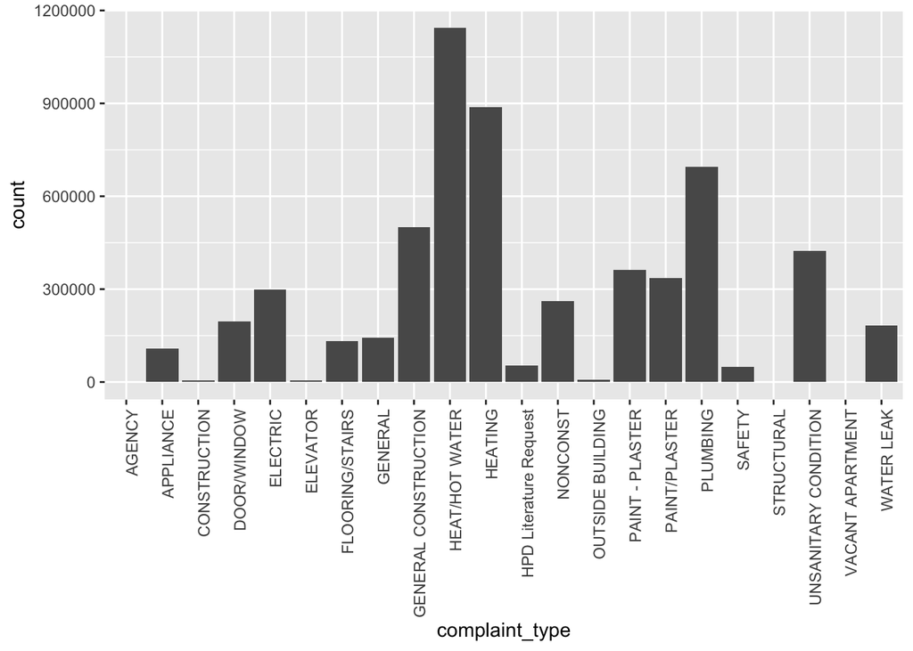

```r
## we can visulize the complaints type and number of complainted in the bar plot

df_NYC %>% ggplot(aes(complaint_type))+
geom_bar()+
theme(axis.text.x = element_text(angle = 90, hjust = 1))
```

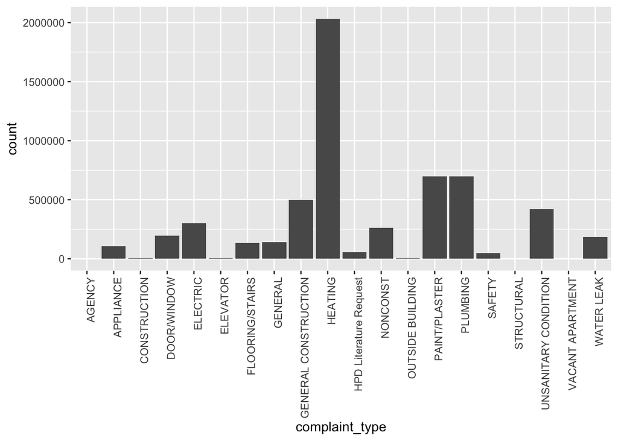

```r
## After reading the New york city data file, one can see that HEAT/HOT WATER complaint column has been merged with HEATING. Similarily for complaint type PAINT - PLASTER. Lets merge them together.

df_NYC$complaint_type[df_NYC$complaint_type %in% "HEAT/HOT WATER"] <- "HEATING"
df_NYC$complaint_type[df_NYC$complaint_type %in% "PAINT - PLASTER"] <- "PAINT/PLASTER"

df_NYC %>% ggplot(aes(complaint_type))+
geom_bar()+
theme(axis.text.x = element_text(angle = 90, hjust = 1))
```

### Temoral Evolution of Complaints Type

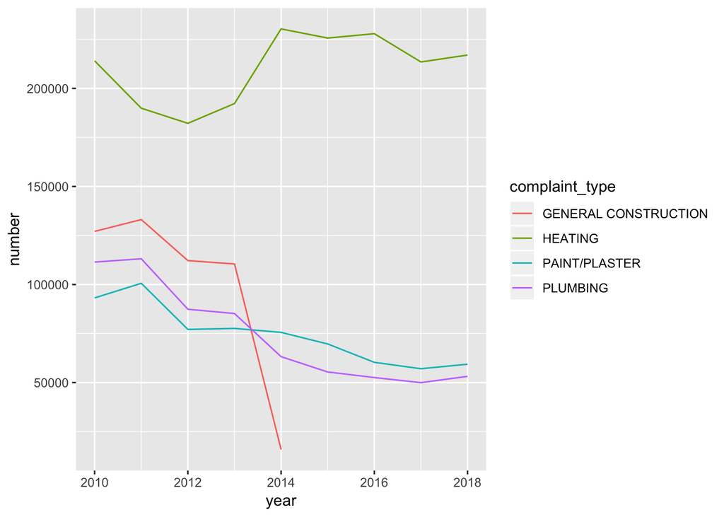

```r
# Convert `timestamp to`POSIXct`
dt <- as.POSIXct(df_NYC$created_date)
df_NYC <- df_NYC %>% mutate(year = format(dt, "%Y"), month = format(dt, "%m"))

rm(dt)

complaint_year <- df_NYC %>%
na.omit() %>% # omit missing values
#select(year, complaint_type) %>% # select columns we are interested in
mutate(year = as.factor(year)) %>% # turn year in factors
mutate(year = as.numeric(levels(year))[year]) %>%
filter(year < 2019) %>%
group_by(year, complaint_type) %>% # group data by year and complaint_Type
summarise(number = n())  # count


complaint_year %>%
filter(complaint_type %in% c("HEATING", "PLUMBING", "GENERAL CONSTRUCTION", "PAINT/PLASTER")) %>%
ggplot(aes(x = year, y = number)) +
geom_line(aes(color=complaint_type)) +
scale_fill_brewer(palette = "Paired")
```

## Concluding Remarks: solution of problem 1: Based on the above plot it is clear that maximum number of complaints are coming from HEAT/HOT water category. So HPD should address the HEAT/HOT WATER complaint first. The problem remails all time high. It is clear with the time dependent plots.

## Problem 2: Should the Department of Housing Preservation and Development of New York City focus on any particular set of boroughs, ZIP codes, or street (where the complaints are severe) for the specific type of complaints you identified in response to Question 1?

```r
# number of complaints for each borough
df_NYC %>%
na.omit() %>% # omit missing values
#select(year, complaint_type) %>% # select columns we are interested in
group_by(borough) %>% # group data by year and complaint_Type
summarise(number = n())  # count
```

```
## # A tibble: 6 x 2
##   borough        number
##   <fct>           <int>
## 1 BRONX         1535504
## 2 BROOKLYN      1660537
## 3 MANHATTAN      999864
## 4 QUEENS         611494
## 5 STATEN ISLAND   83616
## 6 Unspecified    819798
```

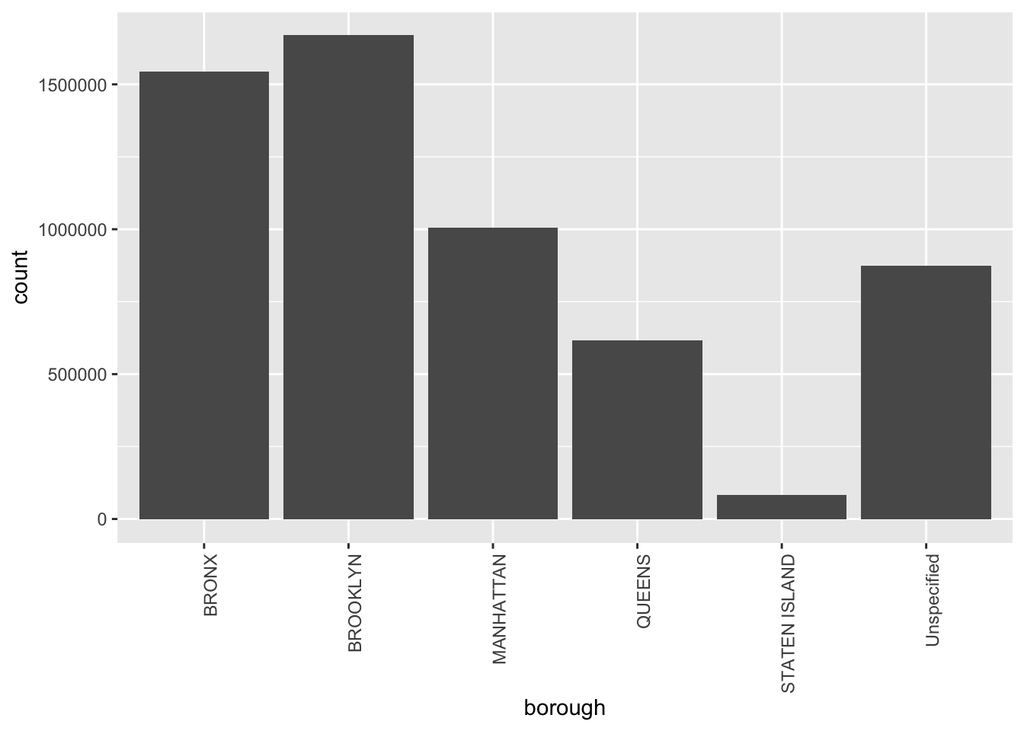

```r
# bar plot for complaints in each borough
df_NYC %>% ggplot(aes(borough))+
geom_bar() +
theme(axis.text.x = element_text(angle = 90, hjust = 1))
```

### This chunk of code produces an interactive map of NYC housing complain area

```r
#lat <- df_NYC$latitude %>% na.omit()
#lng <- df_NYC$longitude %>% na.omit()

#df_geo <- data.frame(lat = runif(1000, min = min(lat), max = max(lat)),
#                    lng = runif(1000, min = min(lng), max = max(lng)))

# The interactive map shows cluster of complaint prone area.

#df_geo %>% leaflet() %>%
#  addTiles() %>%
#  addMarkers(clusterOptions = markerClusterOptions())

# Please note that this map can't be rendered in pdf format.
```

## Concluding Remarks: solution of problem 2:

The bar plot depicts that some boroughs are more severly affected by housing complaints than others. So for further analysis we should particularly focus on 4 boroughs namely ‘BRONOX’, ‘BROOKLYN’, ‘MANHATTAN’, ‘QUEENS’. As a machine learning algorithm are more reliable if we have more feature sets. So in next section we will download some dataset for more details on Housing feathers in the mentioned boroughs.

## Problem 3: Does the Complaint Type that you identified in response to question 1 have an obvious relationship with any particular characteristic or characteristics of the houses or buildings?

```r
# THE ZIP FILE CAN BE DOWNLOADED FROM THE FOLLOWING LINK: "https://www1.nyc.gov/assets/planning/download/zip/data-maps/open-data/nyc_pluto_18v1.zip"

## download file. it may take couple of minutes (fileSize = 46MB).
#dl <- tempfile()
#zip.file.location <- "https://www1.nyc.gov/assets/planning/download/zip/data-maps/open-data/nyc_pluto_18v1.zip"
#download.file(zip.file.location, dl)
#BK_18v1 <- read.csv(unzip(dl,PLUTO_for_WEB/BK_18v1.csv))

#rm(dl)

# I am using my local directory to access the PLUTO files
BK_18v1 <- read.csv('./PLUTO_for_WEB/BK_18v1.csv')
BX_18v1 <- read.csv('./PLUTO_for_WEB/BX_18v1.csv')
MN_18v1 <- read.csv('./PLUTO_for_WEB/MN_18v1.csv')
QN_18v1 <- read.csv('./PLUTO_for_WEB/QN_18v1.csv')

# dimension of data frame
dim(BK_18v1)
```

```
## [1] 277316     87
```

```r
# This gives 87 columns (features). Only few of them are relevant. lets store features that are relevant (idea about this has been suggested here: https://courses.edx.org/courses/course-v1:IBM+DS0720EN+1T2019/courseware/973b7c563b024ec498d5d89fc5a44b9e/dd430df1daac4c5fbbcb0f14b0e74166/1?activate_block_id=block-v1%3AIBM%2BDS0720EN%2B1T2019%2Btype%40vertical%2Bblock%4082f53f93b65c485ebb6ba41a5d23c699)


# The recommended fields are Address, BldgArea, BldgDepth, BuiltFAR, CommFAR, FacilFAR, Lot, LotArea, LotDepth, NumBldgs, NumFloors, OfficeArea, ResArea, ResidFAR, RetailArea, YearBuilt, YearAlter1, ZipCode, YCoord, and XCoord.


df_BK <- BK_18v1 %>% select('Address', 'BldgArea', 'BldgDepth', 'BuiltFAR', 'CommFAR', 'FacilFAR', 'Lot', 'LotArea', 'LotDepth', 'NumBldgs', 'NumFloors', 'OfficeArea', 'ResArea', 'ResidFAR', 'RetailArea', 'YearBuilt', 'YearAlter1', 'ZipCode', 'YCoord', 'XCoord')

df_BX <- BX_18v1 %>% select('Address', 'BldgArea', 'BldgDepth', 'BuiltFAR', 'CommFAR', 'FacilFAR', 'Lot', 'LotArea', 'LotDepth', 'NumBldgs', 'NumFloors', 'OfficeArea', 'ResArea', 'ResidFAR', 'RetailArea', 'YearBuilt', 'YearAlter1', 'ZipCode', 'YCoord', 'XCoord')

df_MN <- MN_18v1 %>% select('Address', 'BldgArea', 'BldgDepth', 'BuiltFAR', 'CommFAR', 'FacilFAR', 'Lot', 'LotArea', 'LotDepth', 'NumBldgs', 'NumFloors', 'OfficeArea', 'ResArea', 'ResidFAR', 'RetailArea', 'YearBuilt', 'YearAlter1', 'ZipCode', 'YCoord', 'XCoord')

df_QN <- QN_18v1 %>% select('Address', 'BldgArea', 'BldgDepth', 'BuiltFAR', 'CommFAR', 'FacilFAR', 'Lot', 'LotArea', 'LotDepth', 'NumBldgs', 'NumFloors', 'OfficeArea', 'ResArea', 'ResidFAR', 'RetailArea', 'YearBuilt', 'YearAlter1', 'ZipCode', 'YCoord', 'XCoord')

# new data frame with smaller features
dim(df_BK)
```

```
## [1] 277316     20
```

```r
# Merge all data frames by rows
df_pluto = rbind(df_BK, df_BX, df_MN, df_QN)

identical(nrow(df_pluto), nrow(df_BK)+nrow(df_BX)+nrow(df_MN)+nrow(df_QN))
```

```
## [1] TRUE
```

```r
rm('df_BK', 'df_BX', 'df_MN', 'df_QN', 'BK_18v1', 'BX_18v1', 'MN_18v1', 'QN_18v1')
# The above dataframes has been successfully merged
```

### Exploratory Analysis

```r
# print the column names
print(colnames(df_NYC))
```

```
##  [1] "created_date"           "unique_key"
##  [3] "complaint_type"         "incident_zip"
##  [5] "incident_address"       "street_name"
##  [7] "address_type"           "city"
##  [9] "resolution_description" "borough"
## [11] "latitude"               "longitude"
## [13] "closed_date"            "location_type"
## [15] "status"                 "year"
## [17] "month"
```

```r
print(colnames(df_pluto))
```

```
##  [1] "Address"    "BldgArea"   "BldgDepth"  "BuiltFAR"   "CommFAR"
##  [6] "FacilFAR"   "Lot"        "LotArea"    "LotDepth"   "NumBldgs"
## [11] "NumFloors"  "OfficeArea" "ResArea"    "ResidFAR"   "RetailArea"
## [16] "YearBuilt"  "YearAlter1" "ZipCode"    "YCoord"     "XCoord"
```

```r
# merge complaint types which were renamed e.g. "HEAT/HOT WATER" to "HEATING" and "PAINT - PLASTER" to "PAINT/PLASTER"
 df_NYC$complaint_type[df_NYC$complaint_type %in% "HEAT/HOT WATER"] <- "HEATING"
 df_NYC$complaint_type[df_NYC$complaint_type %in% "PAINT - PLASTER"] <- "PAINT/PLASTER"

# remove NA entries
df_NYC <- df_NYC %>% na.omit()
```

### Target defnition: Pluto dataset has all houses information for the given borrows. Some houses are register more complain more often. These particular houses have features that can help in predicting future complaints.

```r
df_target <- as.numeric(df_pluto$Address %in% df_NYC$incident_address)


df_pluto['target'] <- df_target

colnames(df_pluto)
```

```
##  [1] "Address"    "BldgArea"   "BldgDepth"  "BuiltFAR"   "CommFAR"
##  [6] "FacilFAR"   "Lot"        "LotArea"    "LotDepth"   "NumBldgs"
## [11] "NumFloors"  "OfficeArea" "ResArea"    "ResidFAR"   "RetailArea"
## [16] "YearBuilt"  "YearAlter1" "ZipCode"    "YCoord"     "XCoord"
## [21] "target"
```

```r
# remove Address column
df_pluto <- df_pluto[-1]
colnames(df_pluto)
```

```
##  [1] "BldgArea"   "BldgDepth"  "BuiltFAR"   "CommFAR"    "FacilFAR"
##  [6] "Lot"        "LotArea"    "LotDepth"   "NumBldgs"   "NumFloors"
## [11] "OfficeArea" "ResArea"    "ResidFAR"   "RetailArea" "YearBuilt"
## [16] "YearAlter1" "ZipCode"    "YCoord"     "XCoord"     "target"
```

```r
# to make sure every column has numeric/integer class
sapply(df_pluto, class)
```

```
##   BldgArea  BldgDepth   BuiltFAR    CommFAR   FacilFAR        Lot
##  "integer"  "numeric"  "numeric"  "numeric"  "numeric"  "integer"
##    LotArea   LotDepth   NumBldgs  NumFloors OfficeArea    ResArea
##  "integer"  "numeric"  "integer"  "numeric"  "integer"  "integer"
##   ResidFAR RetailArea  YearBuilt YearAlter1    ZipCode     YCoord
##  "numeric"  "integer"  "integer"  "integer"  "integer"  "integer"
##     XCoord     target
##  "integer"  "numeric"
```